# 9. Nonparametric Statistics - Wilcoxon-Mann-Whitney test

Author

Lieven Clement

Published

Invalid Date

# 1 Intro

Inferentie is alleen correct als de assumpties over de verdelingen correct zijn.

- e.g Normale verdeling
- gelijke variantie
- De $p$-waarde: $\text{P}_0\left[ \vert T\vert \geq \vert t \vert \right]$.
  - Berekend met de nulverdeling van $T$ die we hebben afgeleid onder de assumpties
  - Onjuist als aannames worden geschonden
- $95\%$ BI bouwt ook voort op deze assumpties Als ze ongeldig zijn, bevatten de intervallen niet de populatieparameter met een waarschijnlijkheid van 95%.
- Asymptotische theorie is moeilijker te plaatsen: de $t$-test is asymptotisch niet-parametrisch omdat voor zeer grote steekproeven de verdelingsveronderstellingen van normaliteit niet langer belangrijk zijn.
- Indien de assumpties correct zijn, dan is de parametrische benadering:
  - efficiënter: grotere power met dezelfde steekproefgrootte + kleinere BI
  - flexibeler: eenvoudiger om gegevens te analyseren met complexe ontwerpen

## 1.1 Cholesterol voorbeeld

- Cholesterolconcentratie in bloed gemeten voor
  - 5 patiënten (groep = 1) twee dagen na een beroerte
  - 5 gezonde proefpersonen (groep = 2).
- Is de cholesterolconcentratie van hartpatiënten en gezonde proefpersonen gemiddeld verschillend?

```r
chol <- read_tsv("https://raw.githubusercontent.com/statOmics/sbc/master/data/chol.txt")
chol$group <- as.factor(chol$group)
nGroups <- table(chol$group)
n <- sum(nGroups)
chol
```

```
# A tibble: 10 × 2
   group cholest
   <fct>   <dbl>
 1 1         244
 2 1         206
 3 1         242
 4 1         278
 5 1         236
 6 2         188
 7 2         212
 8 2         186
 9 2         198
10 2         160
```

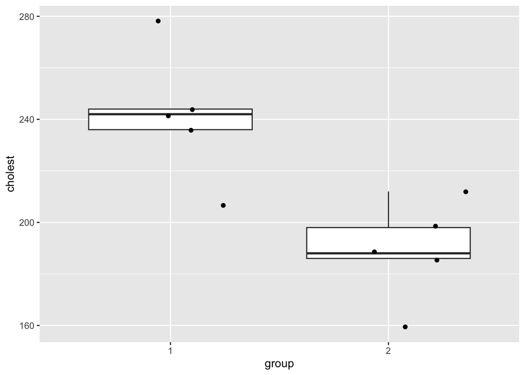

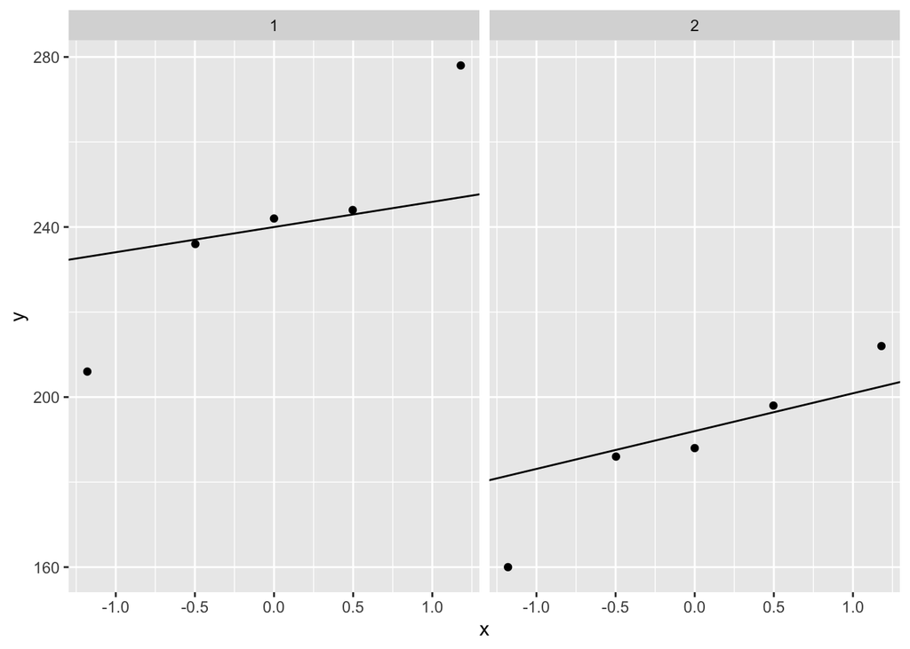

- Mogelijk uitschieters
- Moeilijk om verdelingsaannames te beoordelen wanneer er slechts 5 waarnemingen beschikbaar zijn.

# 2 Rank Tests

- Belangrijke groep niet-parametrische tests
  - niet-parametrisch,
  - Exacte $p$-waarden met behulp van een permutatie-null-distributie.
  - Geen aparte permutatiedistributie nodig voor elke nieuwe dataset
  - Permutatie nulverdeling van rangtesten hangt alleen af van de steekproefgrootte
  - Robuust voor uitschieters

# 3 Ranks

Rangtesten beginnen met in rang getransformeerde gegevens.

- Laat $Y_1, \ldots, Y_n$.
- In de afwezigheid van *gedeelde plaatsen*
  $$R_i=R(Y_i) = \#\{Y_j: Y_j\leq Y_i; j=1,\ldots, n\}$$
- Kleinste waarneming heeft rang 1, tweede kleinste rang 2, …, grootste waarneming krijgt rang $n$

```r
chol$cholest
```

```
 [1] 244 206 242 278 236 188 212 186 198 160
```

```r
rank(chol$cholest)
```

```
 [1]  9  5  8 10  7  3  6  2  4  1
```

## 3.1 Gedeelde plaatsen

Soms zijn er *gedeelde plaatsen*: twee waarnemingen met identieke waarden

```r
withTies=c(403,507,507,610,651,651,651,830,900)
rank(withTies)
```

```
[1] 1.0 2.5 2.5 4.0 6.0 6.0 6.0 8.0 9.0
```

- Gedeelde plaatsen: 507 komt twee keer voor, 651 komt drie keer voor
- Indien er gedeelde plaatsen zijn worden *midranks* gebruikt.
- **midrank** van observatie $Y_i$ wordt
  $$\begin{eqnarray*}
  R_i &=& \frac{ \#\{Y_j: Y_j\leq Y_i\} + ( \#\{Y_j: Y_j < Y_i\} +1)}{2}.
  \end{eqnarray*}$$

## 3.2 Ranks van gepoolde steekproef

- Laat $Y_{ij}$, $i=1,\ldots, n_j$ waarnemingen zijn van twee behandeling groepen $j=1,2$.
- Ze kunnen ook worden weergegeven door $Z_1,\ldots, Z_n$ ($n=n_1+n_2$), de uitkomsten van de gepoolde steekproef

```r
t(chol)
```

```
        [,1]  [,2]  [,3]  [,4]  [,5]  [,6]  [,7]  [,8]  [,9]  [,10]
group   "1"   "1"   "1"   "1"   "1"   "2"   "2"   "2"   "2"   "2"
cholest "244" "206" "242" "278" "236" "188" "212" "186" "198" "160"
```

```r
z=chol$cholest
z
```

```
 [1] 244 206 242 278 236 188 212 186 198 160
```

```r
rank(z)
```

```
 [1]  9  5  8 10  7  3  6  2  4  1
```

# 4 Wilcoxon-Mann-Whitney Test

Gelijktijdig ontwikkeld door Wilcoxon, en, Mann and Whitney: **Wilcoxon-Mann-Whitney**, **Wilcoxon rank sum test** of **Mann-Whitney U test**

## 4.1 hypotheses

Onder $H_0$ is de verdeling van de twee groepen gelijk
$$H_0: f_1=f_2$$

Onder het alternatief $H_1$ verschillen de distributies in locatie
$$H_1: \mu_1\neq \mu_2$$

$H_1$ gaat uit van **locatie-shift**, we zullen deze assumptie later versoepelen.

## 4.2 Test statistiek

Klassieke T-test: verschil in steekproefgemiddelde $\bar{Y}_1-\bar{Y}_2$.

hier: Verschil in steekproefgemiddelden op basis van in rangorde getransformeerde gegevens

Rangen op basis van de gepoolde steekproef (bij samenvoeging van de waarnemingen van de twee groepen): $R_{ij}=R(Y_{ij})$ is de waarnemingsrang $Y_{ij}$ in de gepoolde steekproef.

## 4.3 Standardized statistic

Asymptotisch volgt de gestandaardiseerde statistiek een standaard normale verdeling!

## 4.4 Cholesterol voorbeeld

We illustreren het resultaat voor het cholesterolvoorbeeld met de R-functie `wilcox.test`.

```r
wilcox.test(cholest~group,data=chol)
```

```
    Wilcoxon rank sum exact test

data:  cholest by group
W = 24, p-value = 0.01587
alternative hypothesis: true location shift is not equal to 0
```

- We verwerpen $H_0$ ($p=$ 0.016 $<0.05$)
- De output toont $W=$ 24?
- Bereken

```r
S1 <- sum(rank(chol$cholest)[chol$group==1])
S1
```

```
[1] 39
```

```r
S2 <- sum(rank(chol$cholest)[chol$group==2])
S2
```

```
[1] 16
```

- Waar komt $W=$ 24 vandaan?

## 4.5 Mann and Whitney test

- met $\text{I}\left\{.\right\}$ een indicator die gelijk is aan 1 als de uitdrukking waar is en anders nul.
- U telt hoe vaak een waarneming van de eerste groep groter of gelijk is aan een waarneming uit de tweede groep.

```r
y1=subset(chol,group==1)$cholest
y2=subset(chol,group==2)$cholest
u1Hlp=sapply(y1,function(y1i,y2) {y1i>=y2},y2=y2)
colnames(u1Hlp)=y1;rownames(u1Hlp)=y2
```

```r
u1Hlp
```

```
     244   206  242  278  236
188 TRUE  TRUE TRUE TRUE TRUE
212 TRUE FALSE TRUE TRUE TRUE
186 TRUE  TRUE TRUE TRUE TRUE
198 TRUE  TRUE TRUE TRUE TRUE
160 TRUE  TRUE TRUE TRUE TRUE
```

```r
U1=sum(u1Hlp); U1
```

```
[1] 24
```

Het kan worden aangetoond dat $U_1 = S_1 - \frac{1}{2}n_1(n_1+1).$

```r
S1-nGroups[1]*(nGroups[1]+1)/2
```

```
 1
24
```

1. $U_1$ en $S_1$ bevatten dezelfde informatie
2. $U_1$ is ook een rang statistiek, en
3. Exacte test gebaseerd op $U_1$ en $S_1$ zijn gelijkwaardig.

## 4.6 Probabilistic index

- $U_1$ heeft een betere interpretatie
- Laat $Y_j$ een willekeurige waarneming uit groep $j$ ($j=1,2$) zijn. Dan
  $$\begin{eqnarray*}
  \frac{1}{n_1n_2}\text{E}\left[U_1\right]
  &=& \text{P}\left[Y_1 \geq Y_2\right].
  \end{eqnarray*}$$

We kunnen dus de kans schatten door het gemiddelde te berekenen van alle indicatorvariabele waarden $\text{I}\left\{Y_{i1}\geq Y_{k2}\right\}$. Merk op dat we $n_1 \times n_2$ vergelijkingen hebben gemaakt

```r
mean(u1Hlp)
```

```
[1] 0.96
```

```r
U1/(nGroups[1]*nGroups[2])
```

```
   1
0.96
```

- Waarschijnlijkheid $\text{P}\left[Y_1 \geq Y_2\right]$ wordt de *probabilistische index* genoemd.
- Het is de kans dat een willekeurige waarneming van de eerste groep groter of gelijk is aan een willekeurige waarneming van de tweede groep
- Als $H_0$ geldt $\text{P}\left[Y_1 \geq Y_2\right]=\frac{1}{2}$.
- R functie `wilcox.test` geeft niet de Wilcoxon rank som statistiek terug. Het geeft de Mann-Whitney statistiek $U_1$ terug.
- Laten we het resultaat nog eens bekijken

```r
wTest<-wilcox.test(cholest~group,data=chol)
wTest
```

```
    Wilcoxon rank sum exact test

data:  cholest by group
W = 24, p-value = 0.01587
alternative hypothesis: true location shift is not equal to 0
```

```r
U1
```

```
[1] 24
```

```r
probInd=wTest$statistic/prod(nGroups)
probInd
```

```
   W
0.96
```

Omdat $p=$ 0.0159 $<0.05$ concluderen we op het $5\%$ significantie niveau dat het gemiddelde cholesterolgehalte van hartpatiënten groter is dan dat van gezonde proefpersonen.

- Merk op dat we hebben aangenomen dat het location-shift-model geldig is in deze conclusie.
- We weten ook dat een hoger cholesterolgehalte bij hartpatiënten waarschijnlijker is dan bij gezonde proefpersonen en dat deze kans gelijk is aan $U1/(n_1\times n_2)=$ 96%.
- We moeten de veronderstelling van locatieverschuiving beoordelen. Maar dit is niet mogelijk met slechts 5 waarnemingen.

Zonder de aanname van locatieverschuiving blijft de conclusie in termen van de probabilistische index geldig!

## 4.7 Conclusie

Er is een significant verschil in de verdeling van de cholesterolconcentratie van hartpatiënten twee dagen na een beroerte en die van gezonde proefpersonen (($p=$ 0.0159). bij hartpatiënten is de kans groter dat ze een hoger cholesterolgehalte waarnemen dan bij gezonde proefpersonen. De puntschatter voor deze kans is 96%.